# XAI_hw4

Similarly to the previous homework, we’ll use the “MagicTelescope” dataset. The data is generated to simulate registration of high energy gamma particles. The TARGET column has values either:

- g - gamma (signal) - we’ll denote by 0,
- h - hadron (background) - we’ll denote by 1.

This is an excerpt from the dataset:

|  | Unnamed: 0 | fLength: | fWidth: | fSize: | fConc: | fConc1: | fAsym: | fM3Long: | fM3Trans: | fAlpha: | fDist: | TARGET |
| --- | --- | --- | --- | --- | --- | --- | --- | --- | --- | --- | --- | --- |
| 0 | 0 | 28.7967 | 16.0021 | 2.6449 | 0.3918 | 0.1982 | 27.7004 | 22.0110 | -8.2027 | 40.0920 | 81.8828 | g |
| 1 | 1 | 31.6036 | 11.7235 | 2.5185 | 0.5303 | 0.3773 | 26.2722 | 23.8238 | -9.9574 | 6.3609 | 205.2610 | g |
| 2 | 2 | 162.0520 | 136.0310 | 4.0612 | 0.0374 | 0.0187 | 116.7410 | -64.8580 | -45.2160 | 76.9600 | 256.7880 | g |
| 3 | 3 | 23.8172 | 9.5728 | 2.3385 | 0.6147 | 0.3922 | 27.2107 | -6.4633 | -7.1513 | 10.4490 | 116.7370 | g |
| 4 | 4 | 75.1362 | 30.9205 | 3.1611 | 0.3168 | 0.1832 | -5.5277 | 28.5525 | 21.8393 | 4.6480 | 356.4620 | g |

## Task A

### A1

To make it more interesting, however, this time we'll use CatBoost classifier. CatBoost is a gradient boosting library that uses decision trees. It is similar to XGBoost, but it has some additional features, such as categorical features support. It also has a nice API for hyperparameter tuning, which we'll use in this task.

Due to high computational cost of hyperparameter tuning, we'll use a subset of hyperparameter set I found at [Stack Overflow](https://stackoverflow.com/a/60756492).

The hyperparameters are:

- `depth` - depth of the decision trees,
- `iterations` - number of learning iterations.

The found hyperparameters are:

```
{'depth': 6, 'iterations': 1000}
```

The best model has a good accuracy on the training set:

```
0.930205047318612
```

And on the test set:

```
0.8916929547844374
```

The fact that it's slightly lower than the accuracy on the training set suggests that the model is a bit overfitted. However, the difference is small, so it shouldn't be a problem.

### A2

We select and give predictions about two observations from the test set:

|  | Unnamed: 0 | fLength: | fWidth: | fSize: | fConc: | fConc1: | fAsym: | fM3Long: | fM3Trans: | fAlpha: | fDist: | TARGET |
| --- | --- | --- | --- | --- | --- | --- | --- | --- | --- | --- | --- | --- |
| 6405 | 6405 | 56.3489 | 24.1717 | 2.9857 | 0.2842 | 0.1731 | 21.0311 | 50.8783 | 25.9286 | 5.9280 | 203.755 | g |
| 8523 | 8523 | 32.6585 | 16.7311 | 2.7585 | 0.3522 | 0.1770 | 41.6592 | 23.4397 | -6.9897 | 6.5984 | 148.984 | g |

The predictions are:

```
array([[0.95441539, 0.04558461],
       [0.97388827, 0.02611173]])
```

They strongly suggest that both are gamma particles and not hadrons. As we can see the predictions are correct:

```
6405    0
8523    0
Name: TARGET, dtype: int64
```

### A3

We use the SHAP library to explain the predictions of the model, again using the same two observations:

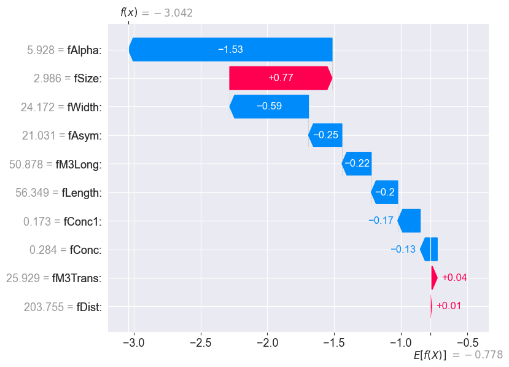

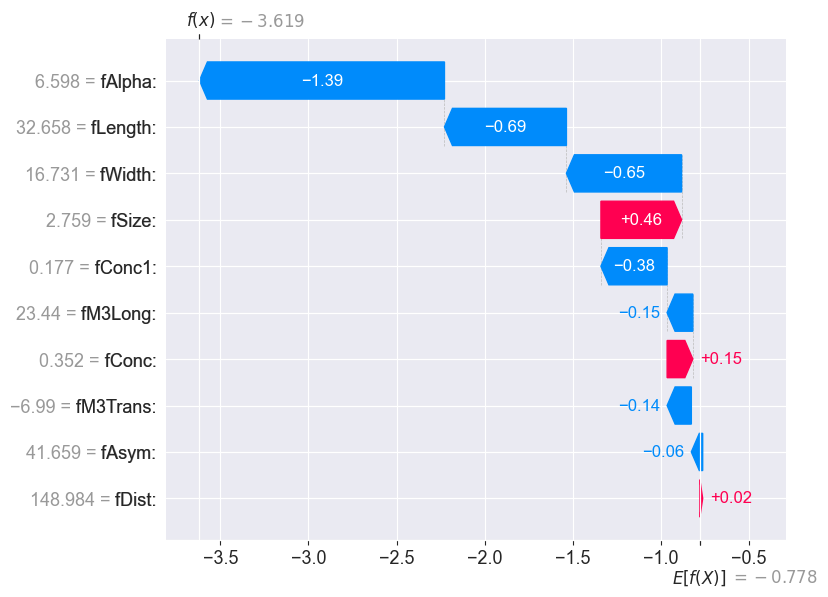

As we can see they both strongly base their predictions on the `fAlpha` feature.

Now, with DALEX:

```
Preparation of a new explainer is initiated

  -> data              : 15216 rows 10 cols
  -> target variable   : Parameter 'y' was a pandas.Series. Converted to a numpy.ndarray.
  -> target variable   : 15216 values
  -> model_class       : catboost.core.CatBoostClassifier (default)
  -> label             : CatBoost
  -> predict function  : <function yhat_proba_default at 0x29355b380> will be used (default)
  -> predict function  : Accepts pandas.DataFrame and numpy.ndarray.
  -> predicted values  : min = 0.000874, mean = 0.351, max = 1.0
  -> model type        : classification will be used (default)
  -> residual function : difference between y and yhat (default)
  -> residuals         : min = -0.968, mean = 0.000129, max = 0.983
  -> model_info        : package catboost

A new explainer has been created!
```

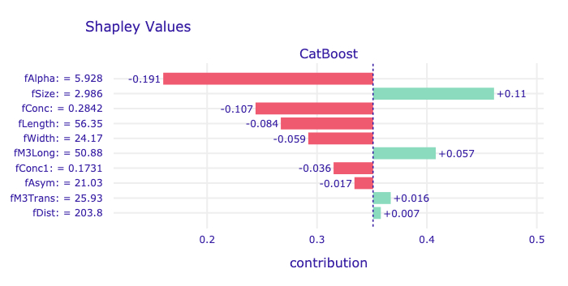

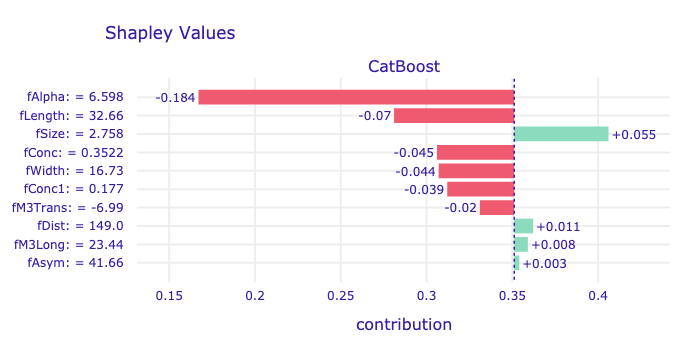

### A4

For tasks 4,5,7 we'll use a sample of a 100 observations from the test set. We'll use the same sample for all three tasks.

```
Stored 'shap_values100' (Explanation)
```

It's not necessary, but we can find all possible pairs of features that are important for at least one observation (the order matters, pair `1.fAlpha, 2.fLength` is different than `1.fLength, 2.fAlpha`).

```
['fLength:,fWidth:',
 'fLength:,fSize:',
 'fLength:,fConc:',
 'fLength:,fAlpha:',
 'fWidth:,fLength:',
 'fWidth:,fSize:',
 'fWidth:,fAlpha:',
 'fSize:,fLength:',
 'fSize:,fWidth:',
 'fSize:,fConc:',
 'fSize:,fM3Long:',
 'fSize:,fAlpha:',
 'fConc:,fWidth:',
 'fConc:,fSize:',
 'fConc:,fAlpha:',
 'fAsym:,fAlpha:',
 'fM3Long:,fWidth:',
 'fM3Long:,fSize:',
 'fM3Long:,fAlpha:',
 'fAlpha:,fLength:',
 'fAlpha:,fWidth:',
 'fAlpha:,fSize:',
 'fAlpha:,fConc:',
 'fDist:,fWidth:']
```

There's 24 of them, which is quite suprising, given that there's 90 such pairs and 100 observations. This suggests that there's a significant overlap between the pairs of features that are important for different observations.

Let's choose random two observations that have a different pair of important features. For one observation it's: `fAlpha, fAsym`, for the other: `fWidth, fSize`.

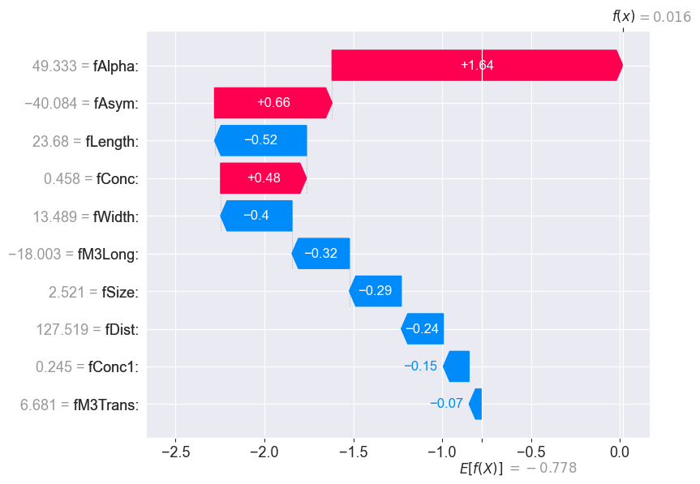

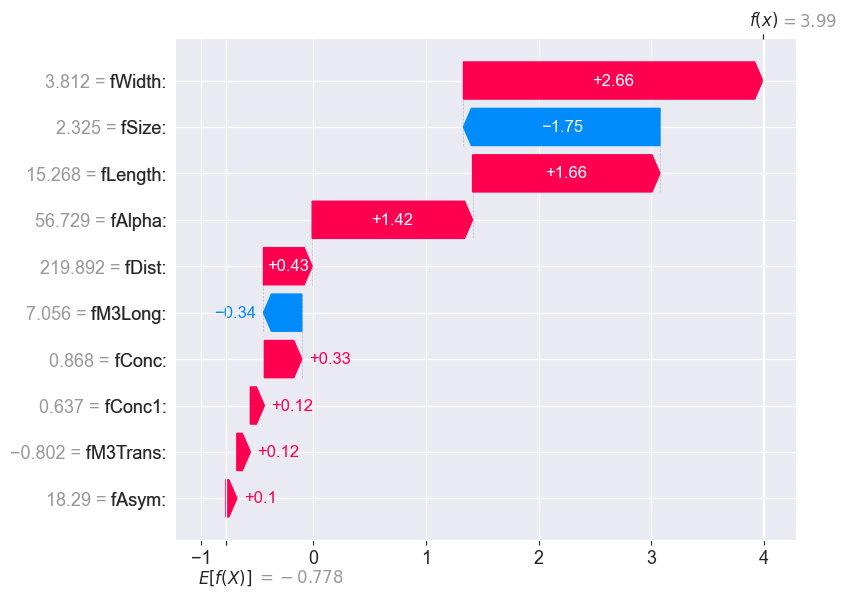

### A5

Let's choose a observation for which the `fAlpha` feature has the biggest positive SHAP value and a different observation for which it has the most negative SHAP value.

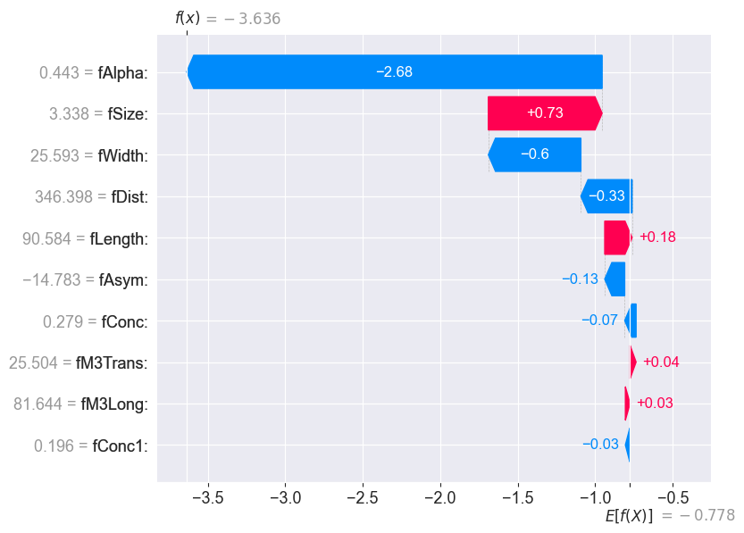

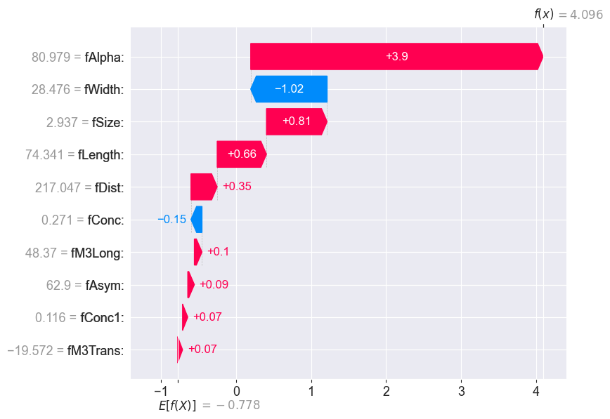

### A6

In task A3, when comparing explanations between `dalex` and `shap`, while the order of importance of features is similar, the values of SHAP values are different. This is because `dalex` uses a different method to calculate SHAP values than `shap`.

Here, SHAP uses a TreeExplainer which is a model-specific and more accurate method, while `dalex` uses a model-agnostic KernelExplainer. The latter is more computationally expensive and less accurate, but it's also more general and can be used for any model.

### A7

Let's train a Multi-Layer Perceptron classifier on the same data:

```
MLPClassifier(max_iter=1000, random_state=789)
```

It achieves worse accuracy on the training set:

```
0.8338590956887487
```

and a slightly worse accuracy on the test set:

```
0.8383280757097792
```

but the accuracies are very close to each other, which suggests the model is not overfitted.

For faster explaining we'll summarize the background as 1000 samples. We'll use the model-agnostic KernelExplainer as I've been unable to find an explainer for the MLP model in the SHAP library.

```
Using 1000 background data samples could cause slower run times. Consider using shap.sample(data, K) or shap.kmeans(data, K) to summarize the background as K samples.
```

```
Stored 'mlp_shap_values100' (Explanation)
```

The KernelExplainer outputs a SHAP value for both classes. To compare it with the `CatBoost` explainer, we'll take the SHAP value for the positive outcome (`h`).

We want to find an observation for which SHAP values between the models vary widely. We'll first normalize each of the SHAP values vector by dividing it by its Euclidean norm. That's because the scale of SHAP values depends on the scale of output of each model.

Then we'll find the observation for which the difference between the normalized SHAP values is the largest.

```
array([ 0.2262257 ,  0.59498041,  0.88445507, -0.46799742,  0.2371656 ,
        0.08438652, -0.7523787 , -0.03010124,  0.444425  ,  0.1266993 ])
```

Let's plot the SHAP values for this observation for the MLP model:

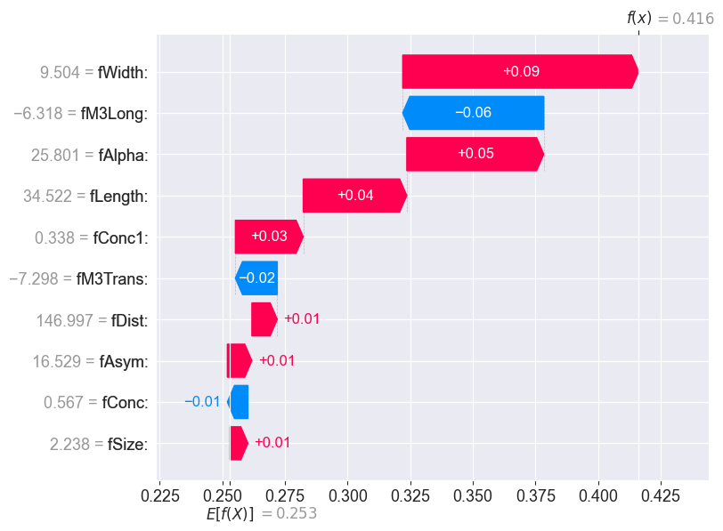

and now for the original CatBoost model:

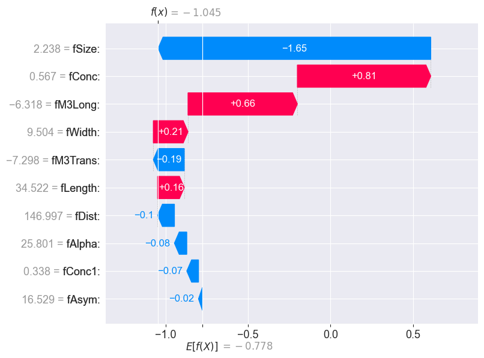

As we can see, the waterfall plots are completely different. For example the `fSize:` feature is the most important for the CatBoost model, but the least important for the MLP model.

## Task B

Using the more efficient subset-based formula from lecture:

$$ \phi_j=\sum_{S \subseteq P /\{j\}} \frac{|S| !(|P|-|S|-1) !}{|P| !}(v(S \cup\{j\})-v(S)) $$

we calculate the Shapley value of `A` to be:

```
65.0
```